# Assignment01

Group 5

#### Data Exploration and Preparation

As the quality of our inputs decide the quality of your output, we will be spending more time and efforts in data exploration, cleaning and preparation. We will be following the below steps for our data exploration and preparation:

1- Variable Identification  
2- Univariate Analysis  
3- Bi-variate Analysis  
4- Missing values treatment  
5- Outlier treatment  
6- Variable transformation  
7- Variable creation

#### 1- Variable Identification

First let’s display and examine the data dictionary or the data columns.

| VARIABLE_NAME | DEFINITION | THEORETICAL_EFFECT |
| --- | --- | --- |
| INDEX | Identification Variable (do not use) | None |
| TARGET_WINS | Number of wins | Target |
| TEAM_BATTING_H | Base Hits by batters (1B,2B,3B,HR) | Positive Impact on Wins |
| TEAM_BATTING_2B | Doubles by batters (2B) | Positive Impact on Wins |
| TEAM_BATTING_3B | Triples by batters (3B) | Positive Impact on Wins |
| TEAM_BATTING_HR | Homeruns by batters (4B) | Positive Impact on Wins |
| TEAM_BATTING_BB | Walks by batters | Positive Impact on Wins |
| TEAM_BATTING_HBP | Batters hit by pitch (get a free base) | Positive Impact on Wins |
| TEAM_BATTING_SO | Strikeouts by batters | Negative Impact on Wins |
| TEAM_BASERUN_SB | Stolen bases | Positive Impact on Wins |
| TEAM_BASERUN_CS | Caught stealing | Negative Impact on Wins |
| TEAM_FIELDING_E | Errors | Negative Impact on Wins |
| TEAM_FIELDING_DP | Double Plays | Positive Impact on Wins |
| TEAM_PITCHING_BB | Walks allowed | Negative Impact on Wins |
| TEAM_PITCHING_H | Hits allowed | Negative Impact on Wins |
| TEAM_PITCHING_HR | Homeruns allowed | Negative Impact on Wins |
| TEAM_PITCHING_SO | Strikeouts by pitchers | Positive Impact on Wins |

We notice that all variables are numeric. The variable names seem to follow certain naming pattern to highlight certain arithmetic relationships. In other words, we can compute the number of ‘1B’ hits by taking the difference between overall hits and ‘2B’, ‘3B’, ‘HR’. Although such naming and construct is not recommended in normalized database design ( as it violates third normal form), it is very frequent practice in the data analytics.

Then , we will identify Predictor (Input) and Target (output) variables. Next, we will identify the data type and category of the variables.

Our predictor input is made of 15 variables. And our dependent variable is one variable called TARGET_WINS.

Below are the variable that have been identified and their respective type and category:

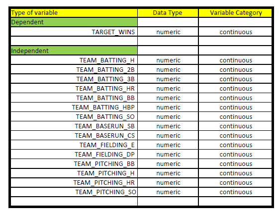

#### 2- Univariate Analysis

At this stage, we explore variables one by one. Method to perform uni-variate analysis will depend on whether the variable type is categorical or continuous. in our case all variables are coutinous. Hence we need to understand the central tendency and spread of each variable. These are measured using various statistical metrics visualization methods:

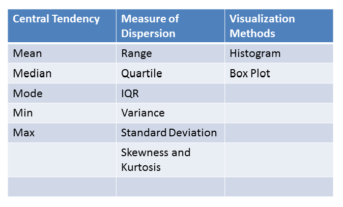

```
##   TARGET_WINS     TEAM_BATTING_H TEAM_BATTING_2B TEAM_BATTING_3B
##  Min.   :  0.00   Min.   : 891   Min.   : 69.0   Min.   :  0.00
##  1st Qu.: 71.00   1st Qu.:1383   1st Qu.:208.0   1st Qu.: 34.00
##  Median : 82.00   Median :1454   Median :238.0   Median : 47.00
##  Mean   : 80.79   Mean   :1469   Mean   :241.2   Mean   : 55.25
##  3rd Qu.: 92.00   3rd Qu.:1537   3rd Qu.:273.0   3rd Qu.: 72.00
##  Max.   :146.00   Max.   :2554   Max.   :458.0   Max.   :223.00
##
##  TEAM_BATTING_HR  TEAM_BATTING_BB TEAM_BATTING_SO  TEAM_BASERUN_SB
##  Min.   :  0.00   Min.   :  0.0   Min.   :   0.0   Min.   :  0.0
##  1st Qu.: 42.00   1st Qu.:451.0   1st Qu.: 548.0   1st Qu.: 66.0
##  Median :102.00   Median :512.0   Median : 750.0   Median :101.0
##  Mean   : 99.61   Mean   :501.6   Mean   : 735.6   Mean   :124.8
##  3rd Qu.:147.00   3rd Qu.:580.0   3rd Qu.: 930.0   3rd Qu.:156.0
##  Max.   :264.00   Max.   :878.0   Max.   :1399.0   Max.   :697.0
##                                   NA's   :102      NA's   :131
##  TEAM_BASERUN_CS TEAM_BATTING_HBP TEAM_PITCHING_H TEAM_PITCHING_HR
##  Min.   :  0.0   Min.   :29.00    Min.   : 1137   Min.   :  0.0
##  1st Qu.: 38.0   1st Qu.:50.50    1st Qu.: 1419   1st Qu.: 50.0
##  Median : 49.0   Median :58.00    Median : 1518   Median :107.0
##  Mean   : 52.8   Mean   :59.36    Mean   : 1779   Mean   :105.7
##  3rd Qu.: 62.0   3rd Qu.:67.00    3rd Qu.: 1682   3rd Qu.:150.0
##  Max.   :201.0   Max.   :95.00    Max.   :30132   Max.   :343.0
##  NA's   :772     NA's   :2085
##  TEAM_PITCHING_BB TEAM_PITCHING_SO  TEAM_FIELDING_E  TEAM_FIELDING_DP
##  Min.   :   0.0   Min.   :    0.0   Min.   :  65.0   Min.   : 52.0
##  1st Qu.: 476.0   1st Qu.:  615.0   1st Qu.: 127.0   1st Qu.:131.0
##  Median : 536.5   Median :  813.5   Median : 159.0   Median :149.0
##  Mean   : 553.0   Mean   :  817.7   Mean   : 246.5   Mean   :146.4
##  3rd Qu.: 611.0   3rd Qu.:  968.0   3rd Qu.: 249.2   3rd Qu.:164.0
##  Max.   :3645.0   Max.   :19278.0   Max.   :1898.0   Max.   :228.0
##                   NA's   :102                        NA's   :286
```

#### 3- Bi-variate Analysis

Bi-variate Analysis finds out the relationship between two variables. Here, we look for association and disassociation between variables at a pre-defined significance level.  
In our case we have only continuous variables we will be doing bi-variate analysis between two continuous variables. We will use scatter plot and find out the relationship between two variables: We are looking to find the pattern and if the relationship between the variables is linear or non-linear.  
Also we will use the scatter plot to show the strength of the relationship between two variable. To find the strength of the relationship, we use Correlation. Correlation varies between -1 and +1.  
-1: perfect negative linear correlation  
+1:perfect positive linear correlation and  
0: No correlation

```
##                  TARGET_WINS TEAM_BATTING_H TEAM_BATTING_2B
## TARGET_WINS        1.0000000    0.388767521      0.28910365
## TEAM_BATTING_H     0.3887675    1.000000000      0.56284968
## TEAM_BATTING_2B    0.2891036    0.562849678      1.00000000
## TEAM_BATTING_3B    0.1426084    0.427696575     -0.10730582
## TEAM_BATTING_HR    0.1761532   -0.006544685      0.43539729
## TEAM_BATTING_BB    0.2325599   -0.072464013      0.25572610
## TEAM_BATTING_SO           NA             NA              NA
## TEAM_BASERUN_SB           NA             NA              NA
## TEAM_BASERUN_CS           NA             NA              NA
## TEAM_BATTING_HBP          NA             NA              NA
## TEAM_PITCHING_H   -0.1099371    0.302693709      0.02369219
## TEAM_PITCHING_HR   0.1890137    0.072853119      0.45455082
## TEAM_PITCHING_BB   0.1241745    0.094193027      0.17805420
## TEAM_PITCHING_SO          NA             NA              NA
## TEAM_FIELDING_E   -0.1764848    0.264902478     -0.23515099
## TEAM_FIELDING_DP          NA             NA              NA
##                  TEAM_BATTING_3B TEAM_BATTING_HR TEAM_BATTING_BB
## TARGET_WINS          0.142608411     0.176153200      0.23255986
## TEAM_BATTING_H       0.427696575    -0.006544685     -0.07246401
## TEAM_BATTING_2B     -0.107305824     0.435397293      0.25572610
## TEAM_BATTING_3B      1.000000000    -0.635566946     -0.28723584
## TEAM_BATTING_HR     -0.635566946     1.000000000      0.51373481
## TEAM_BATTING_BB     -0.287235841     0.513734810      1.00000000
## TEAM_BATTING_SO               NA              NA              NA
## TEAM_BASERUN_SB               NA              NA              NA
## TEAM_BASERUN_CS               NA              NA              NA
## TEAM_BATTING_HBP              NA              NA              NA
## TEAM_PITCHING_H      0.194879411    -0.250145481     -0.44977762
## TEAM_PITCHING_HR    -0.567836679     0.969371396      0.45955207
## TEAM_PITCHING_BB    -0.002224148     0.136927564      0.48936126
## TEAM_PITCHING_SO              NA              NA              NA
## TEAM_FIELDING_E      0.509778447    -0.587339098     -0.65597081
## TEAM_FIELDING_DP              NA              NA              NA
##                  TEAM_BATTING_SO TEAM_BASERUN_SB TEAM_BASERUN_CS
## TARGET_WINS                   NA              NA              NA
## TEAM_BATTING_H                NA              NA              NA
## TEAM_BATTING_2B               NA              NA              NA
## TEAM_BATTING_3B               NA              NA              NA
## TEAM_BATTING_HR               NA              NA              NA
```

[output cut: 47 more lines]

```
## TEAM_BATTING_H                 NA
## TEAM_BATTING_2B                NA
## TEAM_BATTING_3B                NA
## TEAM_BATTING_HR                NA
## TEAM_BATTING_BB                NA
## TEAM_BATTING_SO                NA
## TEAM_BASERUN_SB                NA
## TEAM_BASERUN_CS                NA
## TEAM_BATTING_HBP               NA
## TEAM_PITCHING_H                NA
## TEAM_PITCHING_HR               NA
## TEAM_PITCHING_BB               NA
## TEAM_PITCHING_SO               NA
## TEAM_FIELDING_E                NA
## TEAM_FIELDING_DP                1
```

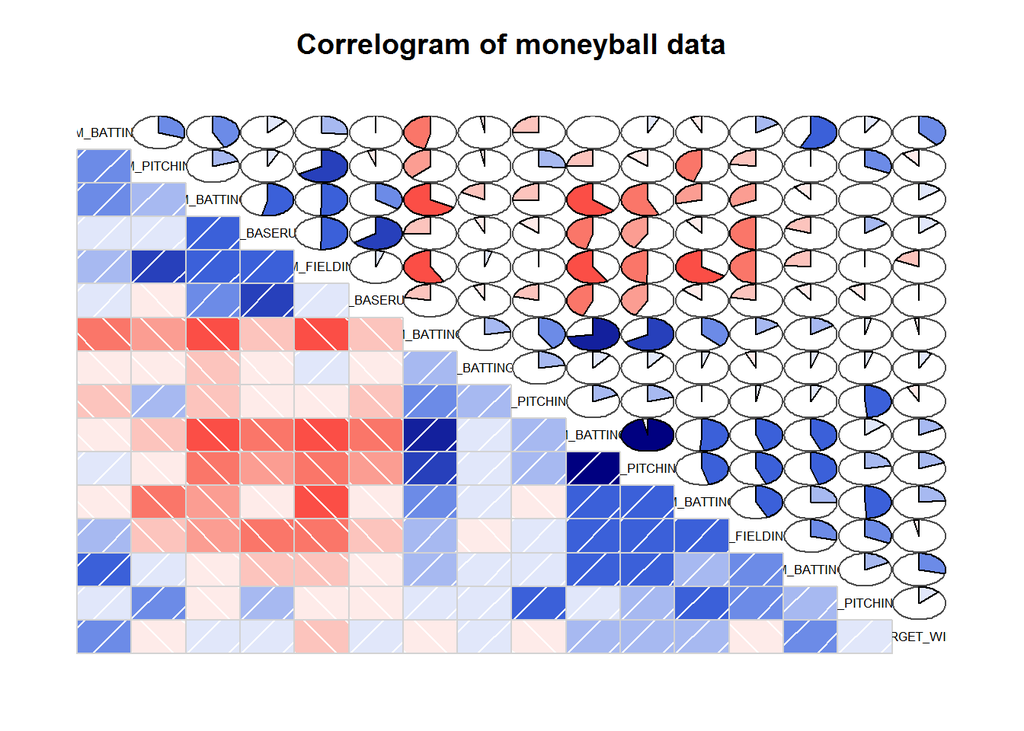

##### Correlation of our dependable variable TARGET_WINS relative to the other 15 independable variables:

```
##
##
##                TEAM_BATTING_H
## ------------  ---------------
## TARGET_WINS         0.3887675
##
##
##                TEAM_BATTING_2B
## ------------  ----------------
## TARGET_WINS          0.2891036
##
##
##                TEAM_BATTING_3B
## ------------  ----------------
## TARGET_WINS          0.1426084
##
##
##                TEAM_BATTING_HR
## ------------  ----------------
## TARGET_WINS          0.1761532
##
##
##                TEAM_BATTING_BB
## ------------  ----------------
## TARGET_WINS          0.2325599
##
##
##                TEAM_BATTING_SO
## ------------  ----------------
## TARGET_WINS                 NA
##
##
##                TEAM_BASERUN_SB
## ------------  ----------------
## TARGET_WINS                 NA
##
##
##                TEAM_BASERUN_CS
## ------------  ----------------
## TARGET_WINS                 NA
```

[output cut: 10 more lines]

```
##
##
##                TEAM_PITCHING_HR
## ------------  -----------------
## TARGET_WINS           0.1890137
##
##
##                TEAM_PITCHING_BB
## ------------  -----------------
## TARGET_WINS           0.1241745
##
##
##                TEAM_PITCHING_SO
## ------------  -----------------
## TARGET_WINS                  NA
```

#### 4- Missing values treatment

Missing data in the training data set can reduce the power / fit of a model or can lead to a biased model because we have not analysed the behavior and relationship with other variables correctly. It can lead to wrong prediction or classification.

First let identify the missing data and find the mean for each variable by excluding the missing the data.

```r
Missing <- c(sum(!complete.cases(moneyball2$TARGET_WINS)),
 sum(!complete.cases(moneyball2$TEAM_BATTING_H)),
 sum(!complete.cases(moneyball2$TEAM_BATTING_2B)),
 sum(!complete.cases(moneyball2$TEAM_BATTING_3B)),
 sum(!complete.cases(moneyball2$TEAM_BATTING_HR)),
 sum(!complete.cases(moneyball2$TEAM_BATTING_BB)),
 sum(!complete.cases(moneyball2$TEAM_BATTING_HBP)),
 sum(!complete.cases(moneyball2$TEAM_BATTING_SO)),
 sum(!complete.cases(moneyball2$TEAM_BASERUN_SB)),
 sum(!complete.cases(moneyball2$TEAM_BASERUN_CS)),
 sum(!complete.cases(moneyball2$TEAM_FIELDING_E)),
 sum(!complete.cases(moneyball2$TEAM_FIELDING_DP)),
 sum(!complete.cases(moneyball2$TEAM_PITCHING_BB)),
 sum(!complete.cases(moneyball2$TEAM_PITCHING_H)),
 sum(!complete.cases(moneyball2$TEAM_PITCHING_HR)),
 sum(!complete.cases(moneyball2$TEAM_PITCHING_SO))
)

Variable<- c('TARGET_WINS',
'TEAM_BATTING_H',
'TEAM_BATTING_2B',
'TEAM_BATTING_3B',
'TEAM_BATTING_HR',
'TEAM_BATTING_BB',
'TEAM_BATTING_HBP',
'TEAM_BATTING_SO',
'TEAM_BASERUN_SB',
'TEAM_BASERUN_CS',
'TEAM_FIELDING_E',
'TEAM_FIELDING_DP',
'TEAM_PITCHING_BB',
'TEAM_PITCHING_H',
'TEAM_PITCHING_HR',
'TEAM_PITCHING_SO'
)

Mean<- c(mean(moneyball2$TARGET_WINS, na.rm=T),
mean(moneyball2$TEAM_BATTING_H, na.rm=T),
mean(moneyball2$TEAM_BATTING_2B, na.rm=T),
mean(moneyball2$TEAM_BATTING_3B, na.rm=T),
mean(moneyball2$TEAM_BATTING_HR, na.rm=T),
mean(moneyball2$TEAM_BATTING_BB, na.rm=T),
mean(moneyball2$TEAM_BATTING_HBP, na.rm=T),
mean(moneyball2$TEAM_BATTING_SO, na.rm=T),
mean(moneyball2$TEAM_BASERUN_SB, na.rm=T),
mean(moneyball2$TEAM_BASERUN_CS, na.rm=T),
mean(moneyball2$TEAM_FIELDING_E, na.rm=T),
mean(moneyball2$TEAM_FIELDING_DP, na.rm=T),
mean(moneyball2$TEAM_PITCHING_BB, na.rm=T),
mean(moneyball2$TEAM_PITCHING_H, na.rm=T),
mean(moneyball2$TEAM_PITCHING_HR, na.rm=T),
mean(moneyball2$TEAM_PITCHING_SO, na.rm=T)
)

Correlation <- c(cor(moneyball2$TARGET_WINS, moneyball2$TARGET_WINS, use = "na.or.complete"),
  cor(moneyball2$TARGET_WINS, moneyball2$TEAM_BATTING_H, use = "na.or.complete"),
  cor(moneyball2$TARGET_WINS, moneyball2$TEAM_BATTING_2B, use = "na.or.complete"),
  cor(moneyball2$TARGET_WINS, moneyball2$TEAM_BATTING_3B, use = "na.or.complete"),
  cor(moneyball2$TARGET_WINS, moneyball2$TEAM_BATTING_HR, use = "na.or.complete"),
  cor(moneyball2$TARGET_WINS, moneyball2$TEAM_BATTING_BB, use = "na.or.complete"),
  cor(moneyball2$TARGET_WINS, moneyball2$TEAM_BATTING_HBP, use = "na.or.complete"),
  cor(moneyball2$TARGET_WINS, moneyball2$TEAM_BATTING_SO, use = "na.or.complete"),
  cor(moneyball2$TARGET_WINS, moneyball2$TEAM_BASERUN_SB, use = "na.or.complete"),
  cor(moneyball2$TARGET_WINS, moneyball2$TEAM_BASERUN_CS, use = "na.or.complete"),
  cor(moneyball2$TARGET_WINS, moneyball2$TEAM_FIELDING_E, use = "na.or.complete"),
  cor(moneyball2$TARGET_WINS, moneyball2$TEAM_FIELDING_DP, use = "na.or.complete"),
  cor(moneyball2$TARGET_WINS, moneyball2$TEAM_PITCHING_BB, use = "na.or.complete"),
  cor(moneyball2$TARGET_WINS, moneyball2$TEAM_PITCHING_H, use = "na.or.complete"),
  cor(moneyball2$TARGET_WINS, moneyball2$TEAM_PITCHING_HR, use = "na.or.complete"),
  cor(moneyball2$TARGET_WINS, moneyball2$TEAM_PITCHING_SO, use = "na.or.complete")
)

df <- data.frame(Variable,"Count Missing Values" = Missing, Mean, Correlation,
            'Theoretical Impact '= moneyballvars$THEORETICAL_EFFECT[2:17])

kable(df)
```

| Variable | Count.Missing.Values | Mean | Correlation | Theoretical.Impact. |
| --- | --- | --- | --- | --- |
| TARGET_WINS | 0 | 80.79086 | 1.0000000 | Target |
| TEAM_BATTING_H | 0 | 1469.26977 | 0.3887675 | Positive Impact on Wins |
| TEAM_BATTING_2B | 0 | 241.24692 | 0.2891036 | Positive Impact on Wins |
| TEAM_BATTING_3B | 0 | 55.25000 | 0.1426084 | Positive Impact on Wins |
| TEAM_BATTING_HR | 0 | 99.61204 | 0.1761532 | Positive Impact on Wins |
| TEAM_BATTING_BB | 0 | 501.55888 | 0.2325599 | Positive Impact on Wins |
| TEAM_BATTING_HBP | 2085 | 59.35602 | 0.0735042 | Positive Impact on Wins |
| TEAM_BATTING_SO | 102 | 735.60534 | -0.0317507 | Negative Impact on Wins |
| TEAM_BASERUN_SB | 131 | 124.76177 | 0.1351389 | Positive Impact on Wins |
| TEAM_BASERUN_CS | 772 | 52.80386 | 0.0224041 | Negative Impact on Wins |
| TEAM_FIELDING_E | 0 | 246.48067 | -0.1764848 | Negative Impact on Wins |
| TEAM_FIELDING_DP | 286 | 146.38794 | -0.0348506 | Positive Impact on Wins |
| TEAM_PITCHING_BB | 0 | 553.00791 | 0.1241745 | Negative Impact on Wins |
| TEAM_PITCHING_H | 0 | 1779.21046 | -0.1099371 | Negative Impact on Wins |
| TEAM_PITCHING_HR | 0 | 105.69859 | 0.1890137 | Negative Impact on Wins |
| TEAM_PITCHING_SO | 102 | 817.73045 | -0.0784361 | Positive Impact on Wins |

#### 5- Outlier treatment

Outliers might make a huge impact on the model if not identified and handled appropriately. Here we identify the outliers and exclude them if they seem to have an impact. To do this, we will first identify the variables with outliers and then check the correlation with and without the outliers to the dependent variable. We will then retain or exclude those outliers that seem to make a difference.  
First lets have a look at all the variables and outliers.

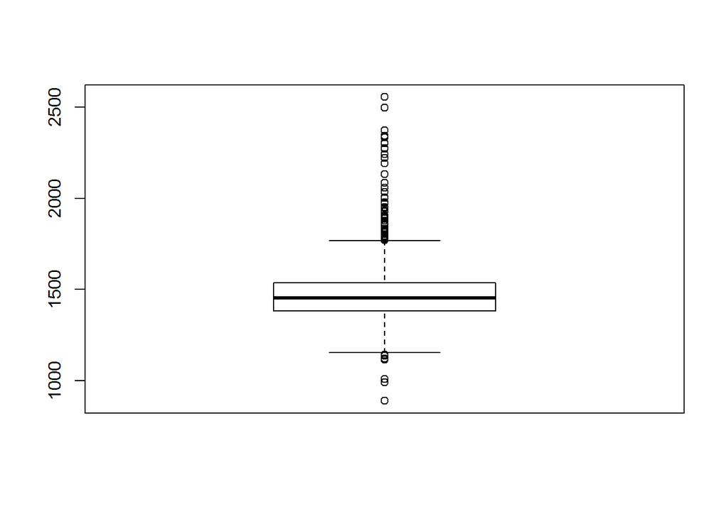

```r
boxplot(moneyball2$TEAM_BATTING_H)
```

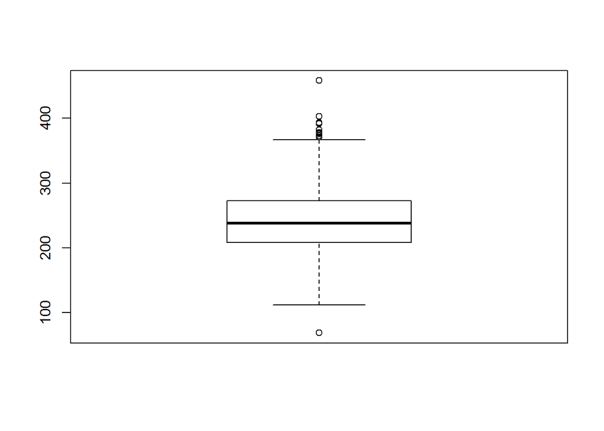

```r
boxplot(moneyball2$TEAM_BATTING_2B)
```

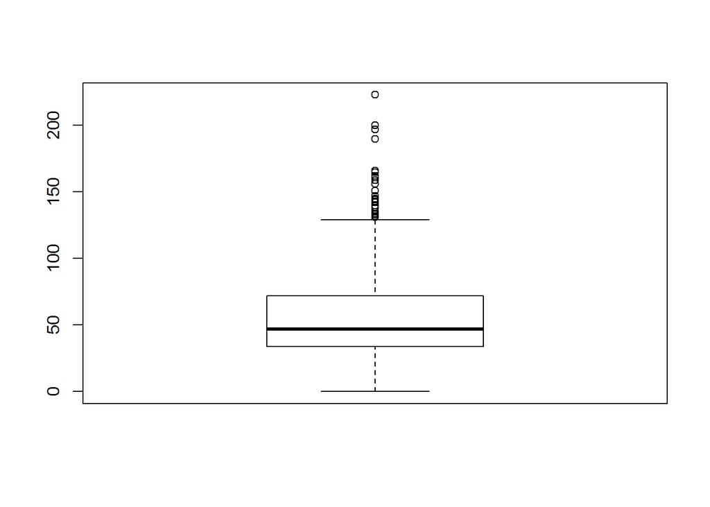

```r
boxplot(moneyball2$TEAM_BATTING_3B)
```

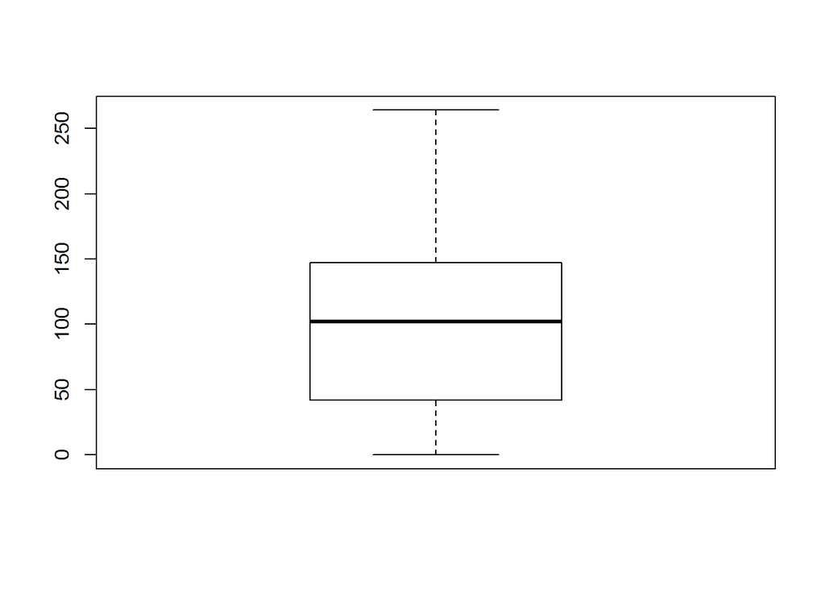

```r
boxplot(moneyball2$TEAM_BATTING_HR)
```

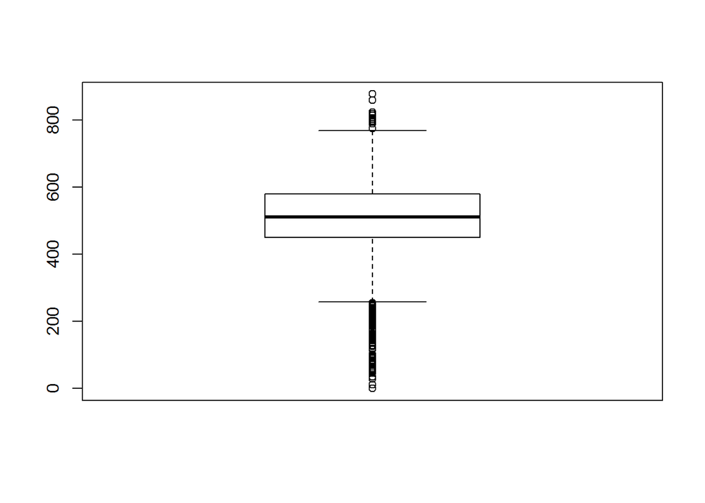

```r
boxplot(moneyball2$TEAM_BATTING_BB)
```

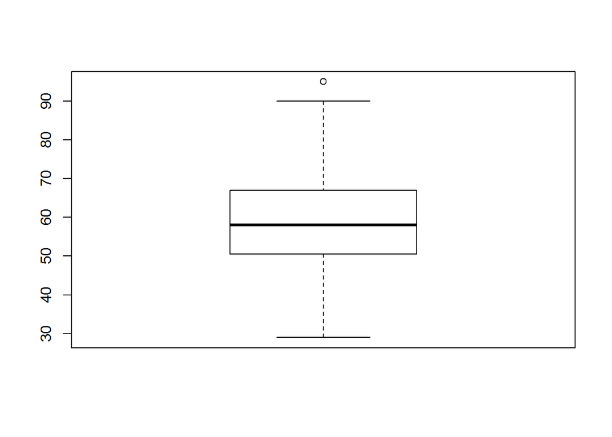

```r
boxplot(moneyball2$TEAM_BATTING_HBP)
```

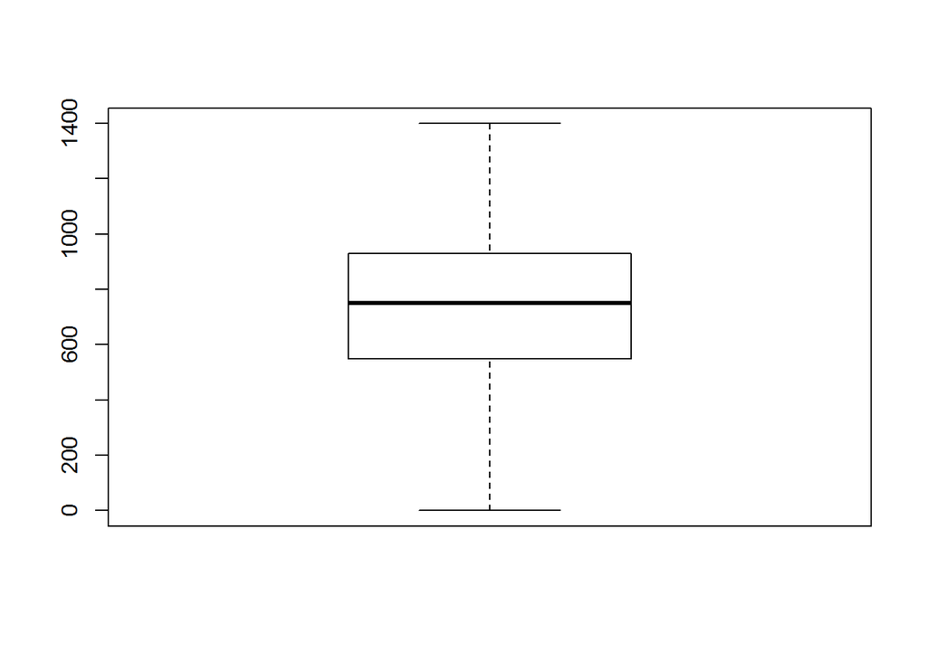

```r
boxplot(moneyball2$TEAM_BATTING_SO)
```

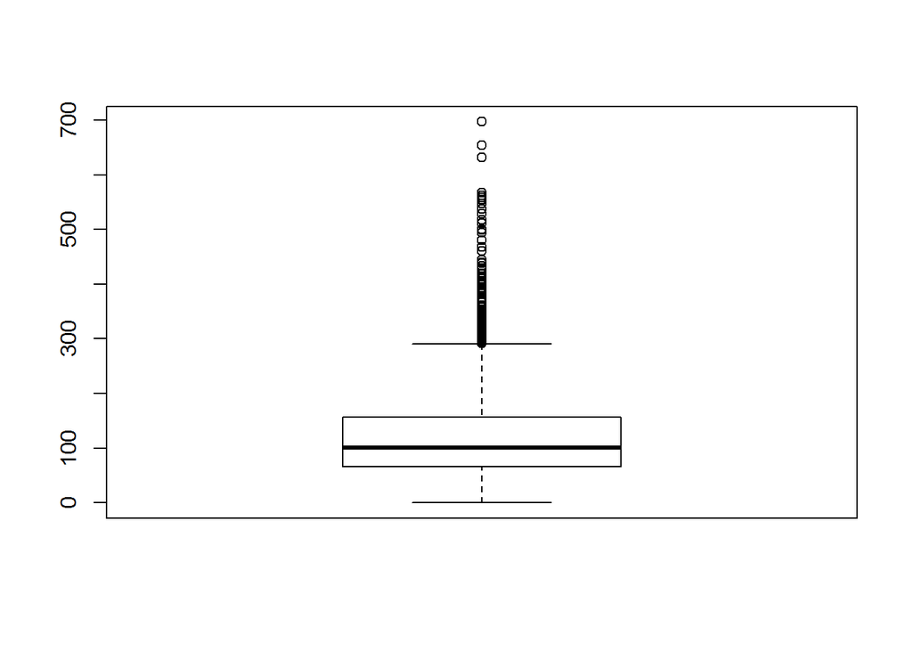

```r
boxplot(moneyball2$TEAM_BASERUN_SB)
```

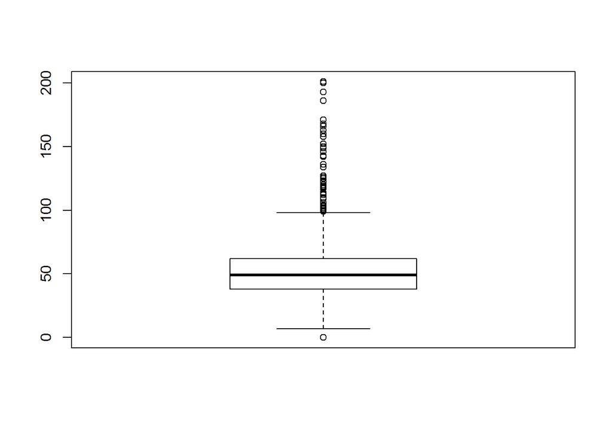

```r
boxplot(moneyball2$TEAM_BASERUN_CS)
```

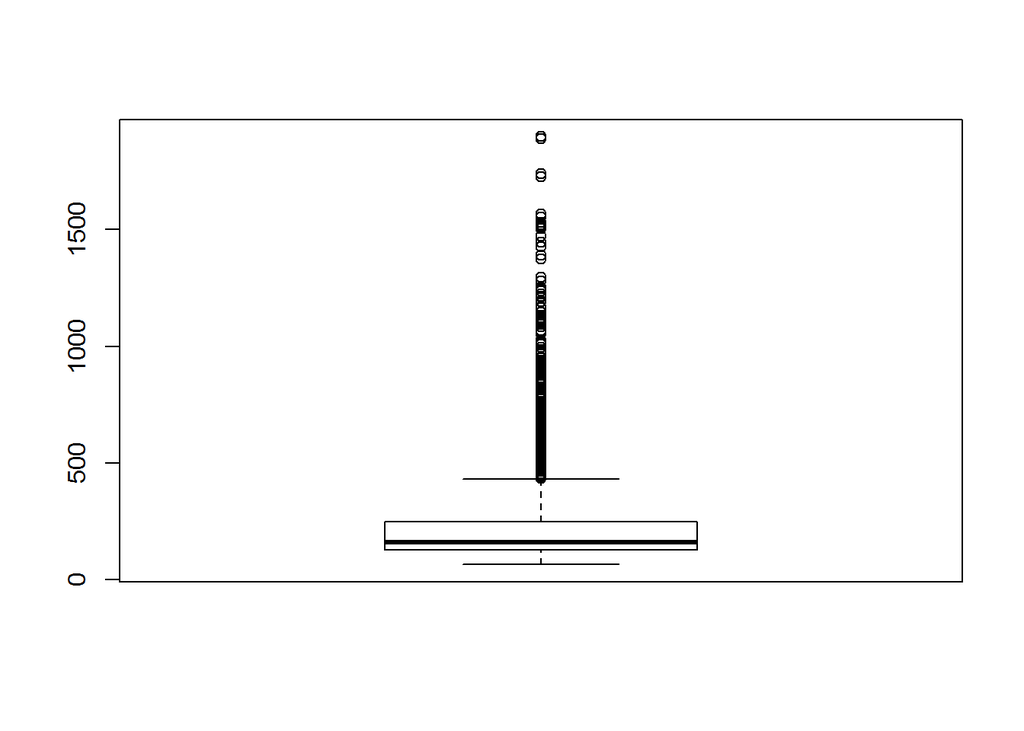

```r
boxplot(moneyball2$TEAM_FIELDING_E)
```

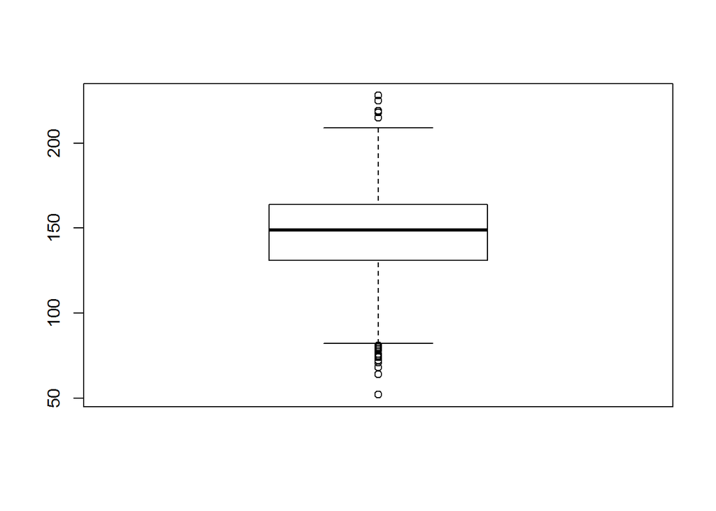

```r
boxplot(moneyball2$TEAM_FIELDING_DP)
```

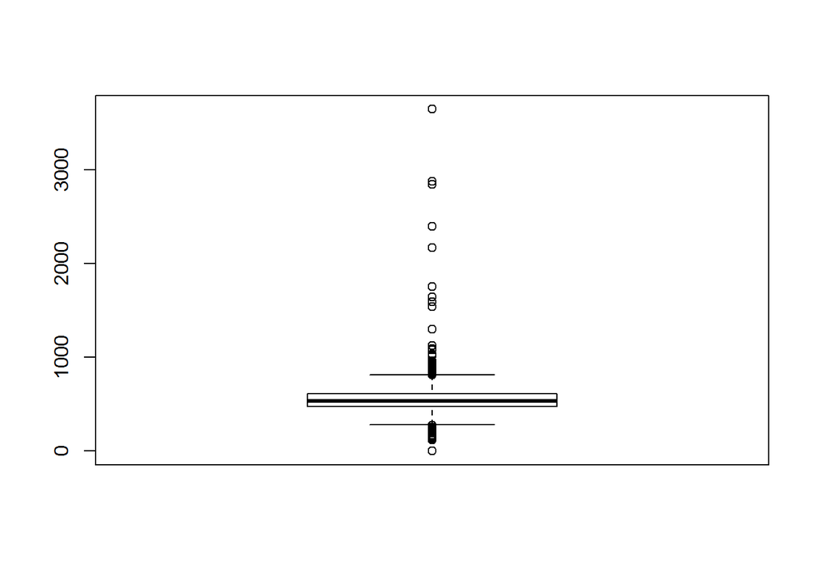

```r
boxplot(moneyball2$TEAM_PITCHING_BB)
```

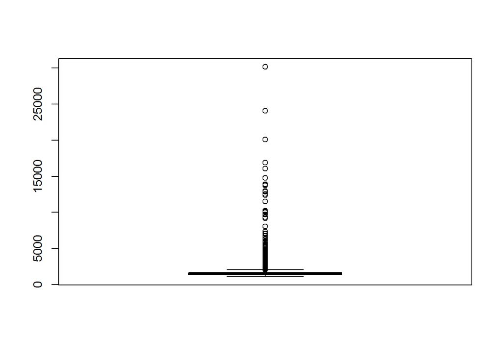

```r
boxplot(moneyball2$TEAM_PITCHING_H)
```

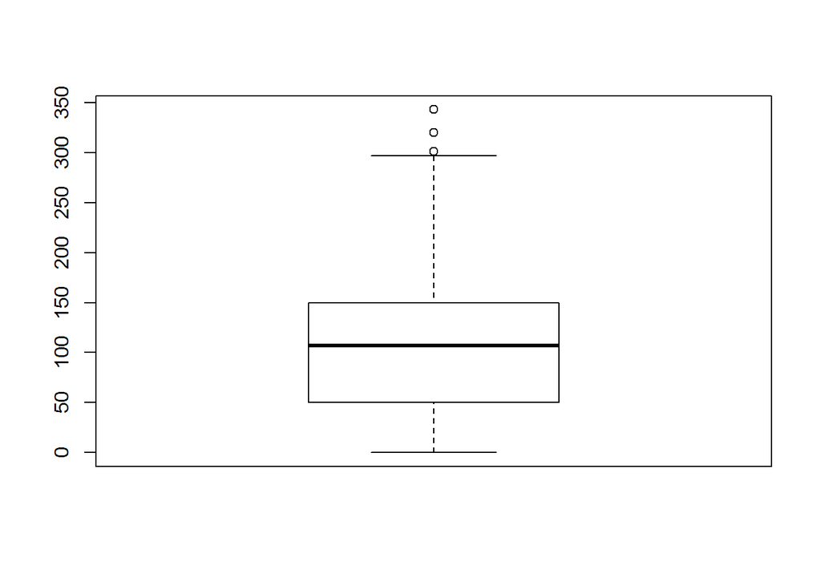

```r
boxplot(moneyball2$TEAM_PITCHING_HR)
```

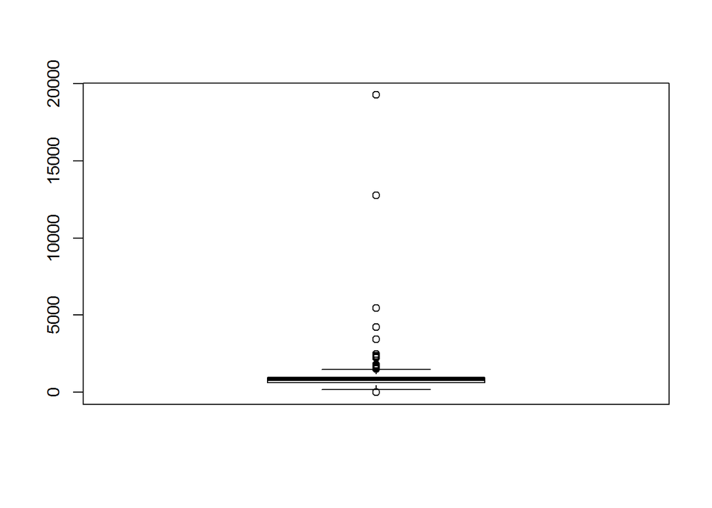

```r
boxplot(moneyball2$TEAM_PITCHING_SO)
```